# Simulation vs Real Data

Author

George Ellis

## 1 Overview

This page compares the behavior of the calibrated single-player simulation model with the hierarchical multi-player model fit to real Lichess data.

The goal is not to force agreement between the two, but to understand where simulation assumptions were too optimistic and how the real data changed the conclusions.

## 2 Why This Comparison Matters

The simulation work suggested that a treatment effect might be detectable under a structured latent-skill model. The real-data analysis showed that:

- ratings are more volatile than initially assumed
- mean reversion is strong
- opponent strength matters
- individual improvement is difficult to identify from rating data alone

This page places those results side by side.

## 3 Simulation: Calibrated Single-Player Model

### 3.1 Simulated Data Snapshot

```python
import pandas as pd

sim = pd.read_csv("simulated_chess_training_data_v2_3_calibrated.csv")
sim.head()
```

|  | game | post | games_post | time_c | time_std | games_post_std | mu_target_true | mu_cf_target_true | skill_true | skill_cf_true | true_treatment_effect | elo_obs | opp_elo |
| --- | --- | --- | --- | --- | --- | --- | --- | --- | --- | --- | --- | --- | --- |
| 0 | 1 | 0 | 0 | -99.5 | -0.995 | 0.0 | 1697.413 | 1697.413 | 1687.521786 | 1687.521786 | 0.0 | 1695.208392 | 1755.362159 |
| 1 | 2 | 0 | 0 | -98.5 | -0.985 | 0.0 | 1697.439 | 1697.439 | 1684.042264 | 1684.042264 | 0.0 | 1713.823916 | 1630.323793 |
| 2 | 3 | 0 | 0 | -97.5 | -0.975 | 0.0 | 1697.465 | 1697.465 | 1697.189972 | 1697.189972 | 0.0 | 1731.356401 | 1737.274073 |
| 3 | 4 | 0 | 0 | -96.5 | -0.965 | 0.0 | 1697.491 | 1697.491 | 1699.135736 | 1699.135736 | 0.0 | 1746.111096 | 1689.696452 |
| 4 | 5 | 0 | 0 | -95.5 | -0.955 | 0.0 | 1697.517 | 1697.517 | 1708.305671 | 1708.305671 | 0.0 | 1715.902425 | 1730.982134 |

### 3.2 Simulated Treatment Effect

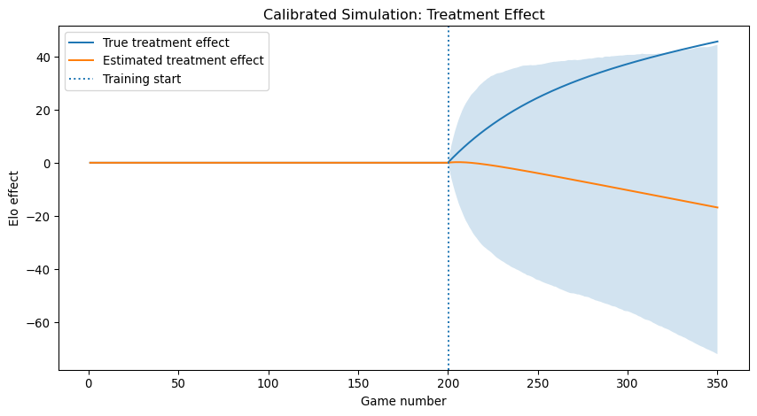

```python
import matplotlib.pyplot as plt

fit_sim = pd.read_csv("model_observation_fits_v2_3_calibrated.csv")

plt.figure(figsize=(9, 5))
plt.plot(fit_sim["game"], fit_sim["true_treatment_effect"], label="True treatment effect")
plt.plot(fit_sim["game"], fit_sim["treatment_effect_mean"], label="Estimated treatment effect")
plt.fill_between(
    fit_sim["game"],
    fit_sim["treatment_effect_lwr"],
    fit_sim["treatment_effect_upr"],
    alpha=0.2
)
plt.axvline(200.5, linestyle=":", label="Training start")
plt.title("Calibrated Simulation: Treatment Effect")
plt.xlabel("Game number")
plt.ylabel("Elo effect")
plt.legend()
plt.tight_layout()
plt.show()
```

### 3.3 Simulated Factual vs Counterfactual Skill

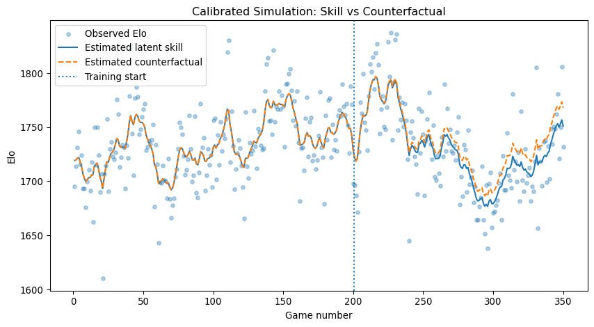

```python
plt.figure(figsize=(9, 5))
plt.scatter(fit_sim["game"], fit_sim["elo_obs"], alpha=0.35, s=16, label="Observed Elo")
plt.plot(fit_sim["game"], fit_sim["skill_mean"], label="Estimated latent skill")
plt.plot(fit_sim["game"], fit_sim["skill_cf_mean"], linestyle="--", label="Estimated counterfactual")
plt.axvline(200.5, linestyle=":", label="Training start")
plt.title("Calibrated Simulation: Skill vs Counterfactual")
plt.xlabel("Game number")
plt.ylabel("Elo")
plt.legend()
plt.tight_layout()
plt.show()
```

## 4 Real Data: Hierarchical Multi-Player Model

### 4.1 Real Data Parameter Summary

```python
real_summary = pd.read_csv("multi_v24_trend_opp_fixed_summary.csv")
real_summary
```

|  | Unnamed: 0 | mean | sd | hdi_3% | hdi_97% | mcse_mean | mcse_sd | ess_bulk | ess_tail | r_hat |
| --- | --- | --- | --- | --- | --- | --- | --- | --- | --- | --- |
| 0 | alpha_pop | 1754.7080 | 35.1017 | 1681.6469 | 1795.9876 | 16.3866 | 8.6408 | 6.9822 | 17.1840 | 1.5614 |
| 1 | sigma_alpha | 64.2953 | 33.7649 | 0.5646 | 98.5210 | 16.1927 | 8.7469 | 7.1367 | 28.5545 | 1.5284 |
| 2 | beta_pop | -18.0583 | 32.9035 | -84.2715 | 11.6167 | 15.8715 | 9.7340 | 7.1113 | 20.3257 | 1.5539 |
| 3 | sigma_beta | 12.0889 | 9.9467 | 0.6929 | 28.4160 | 2.2177 | 2.2571 | 21.7496 | 31.6311 | 1.1442 |
| 4 | kappa | 0.1237 | 0.0733 | 0.0011 | 0.2087 | 0.0341 | 0.0168 | 7.2025 | 23.5010 | 1.5429 |
| 5 | sigma_state | 13.6571 | 1.6023 | 10.4123 | 16.2946 | 0.5875 | 0.2139 | 8.5699 | 55.5543 | 1.4328 |
| 6 | sigma_obs | 153.7186 | 9.2324 | 136.6730 | 170.4777 | 3.0747 | 1.0170 | 9.8694 | 35.9264 | 1.3421 |
| 7 | gamma | 0.6763 | 0.0199 | 0.6396 | 0.7129 | 0.0049 | 0.0008 | 16.9807 | 68.5171 | 1.1707 |

### 4.2 Distribution of Real Player Trend Estimates

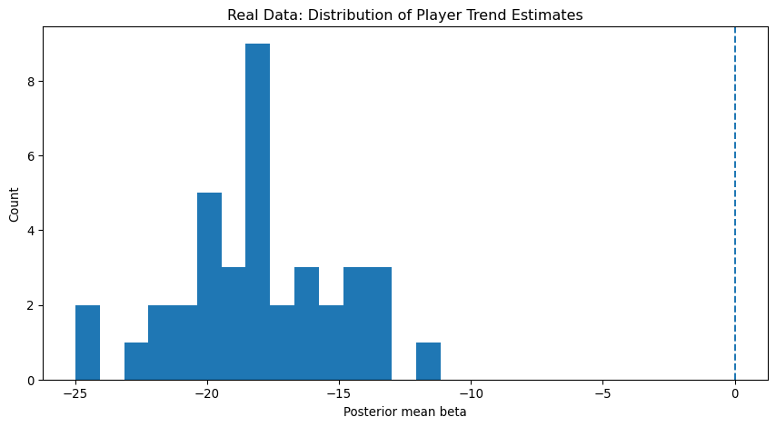

```python
real_trends = pd.read_csv("multi_v24_player_trends_opp_fixed.csv")

plt.figure(figsize=(9, 5))
plt.hist(real_trends["beta_mean"], bins=15)
plt.axvline(0, linestyle="--")
plt.title("Real Data: Distribution of Player Trend Estimates")
plt.xlabel("Posterior mean beta")
plt.ylabel("Count")
plt.tight_layout()
plt.show()
```

### 4.3 Real Data: Strongest Evidence Table

```python
real_trends.sort_values("evidence_strength", ascending=False).head(10)
```

|  | player_id | username | alpha_mean | alpha_lwr | alpha_upr | beta_mean | beta_lwr | beta_upr | prob_beta_positive | elo_change_mean | elo_change_lwr | elo_change_upr | trajectory_class | evidence_strength |
| --- | --- | --- | --- | --- | --- | --- | --- | --- | --- | --- | --- | --- | --- | --- |
| 0 | 28 | ronaldfischer | 1638.184799 | 1592.032996 | 1709.240843 | -24.989288 | -95.427635 | 8.536823 | 0.17000 | -49.978577 | -190.855270 | 17.073646 | stable/uncertain | 0.33000 |
| 1 | 4 | berezinnk | 1829.324262 | 1682.810077 | 1899.466678 | -24.079564 | -113.066586 | 13.071068 | 0.27500 | -48.159129 | -226.133173 | 26.142136 | stable/uncertain | 0.22500 |
| 2 | 10 | genom1 | 1798.773700 | 1683.554951 | 1857.336859 | -22.119345 | -107.610210 | 14.797438 | 0.30000 | -44.238691 | -215.220420 | 29.594877 | stable/uncertain | 0.20000 |
| 3 | 36 | wallstjesus | 1694.319453 | 1664.916440 | 1724.649458 | -19.469785 | -96.947734 | 15.583837 | 0.31325 | -38.939571 | -193.895469 | 31.167675 | stable/uncertain | 0.18675 |
| 4 | 30 | sandrinod | 1681.134870 | 1649.980382 | 1713.534821 | -18.463614 | -95.230488 | 16.259548 | 0.31475 | -36.927228 | -190.460976 | 32.519095 | stable/uncertain | 0.18525 |
| 5 | 23 | oleg081969 | 1724.920698 | 1680.351652 | 1758.782921 | -19.933687 | -100.694316 | 15.682887 | 0.31975 | -39.867375 | -201.388632 | 31.365774 | stable/uncertain | 0.18025 |
| 6 | 22 | ns71 | 1773.080941 | 1682.356538 | 1821.728660 | -20.314042 | -103.850574 | 16.305394 | 0.32125 | -40.628084 | -207.701148 | 32.610789 | stable/uncertain | 0.17875 |
| 7 | 19 | napetting_main | 1812.111941 | 1680.984813 | 1875.117223 | -21.350565 | -107.339243 | 15.034740 | 0.32850 | -42.701130 | -214.678486 | 30.069479 | stable/uncertain | 0.17150 |
| 8 | 6 | bharath07 | 1783.214747 | 1678.391502 | 1837.879103 | -20.698707 | -105.879813 | 16.613704 | 0.33150 | -41.397415 | -211.759627 | 33.227408 | stable/uncertain | 0.16850 |
| 9 | 27 | renameduser | 1770.218627 | 1679.151522 | 1827.621215 | -20.684754 | -108.429947 | 18.610321 | 0.33925 | -41.369509 | -216.859894 | 37.220643 | stable/uncertain | 0.16075 |

## 5 Direct Comparison

### 5.1 Simulation vs Real Data Parameter Table

```python
import numpy as np

def get_mean(df, var):
    return float(df.loc[df["Unnamed: 0"] == var, "mean"].iloc[0])

comparison = pd.DataFrame({
    "Quantity": ["kappa", "sigma_state", "sigma_obs_or_elo"],
    "Simulation (calibrated truth)": [0.02, 10.0, 25.0],
    "Real data posterior mean": [
        get_mean(real_summary, "kappa"),
        get_mean(real_summary, "sigma_state"),
        get_mean(real_summary, "sigma_obs"),
    ],
})
comparison
```

|  | Quantity | Simulation (calibrated truth) | Real data posterior mean |
| --- | --- | --- | --- |
| 0 | kappa | 0.02 | 0.1237 |
| 1 | sigma_state | 10.00 | 13.6571 |
| 2 | sigma_obs_or_elo | 25.00 | 153.7186 |

### 5.2 Main Contrast

The simulation assumed an explicit treatment beginning at game 200 and therefore produced a factual/counterfactual comparison by construction.

The real data contain no treatment dates. As a result:

- the real-data model is descriptive rather than causal
- it estimates latent player trajectories, not intervention effects
- it shows that most player-specific trends are too uncertain to interpret as clear improvement

## 6 Interpretation

The simulation was useful for learning how a counterfactual model behaves under controlled conditions. The real data then showed that actual rating dynamics are noisier, more heterogeneous, and more heavily shaped by opponent strength than the early simulation work assumed.

This leads to a practical conclusion:

> A simple before/after improvement claim is much easier to produce in simulation than to justify in real rating data.

## 7 Takeaway

The most important lesson from comparing simulation and real data is that the limiting factor is not just model sophistication. It is the information content of the data.

Without actual treatment dates or external training information, rating data alone support only cautious descriptive conclusions about improvement.

## 8 Navigation

Return to the main page here:

Back to main analysis